# My answers

Hamed Vaheb

2021-12-02

# 1. Simple linear model

> In order to tryout linear models in *R* we are going to use the `blood_fat` dataset which contains the *age* (in years), *weight* (in kg) and measured *fat concentrations* (units were not mentioned) in blood samples of different subjects.

## Relation of blood fat content and age

We would like to determine whether the blood concentration in fat is related to the age of the subjects.

1. load the data (`csv`) available here in R

```r
# Write your answer here

blood_fat <- readr::read_delim("data/blood_fat.csv")
blood_fat
```

```
## # A tibble: 25 × 5
##       id   one weight   age   fat
##    <dbl> <dbl>  <dbl> <dbl> <dbl>
##  1     1     1     84    46   354
##  2     2     1     73    20   190
##  3     3     1     65    52   405
##  4     4     1     70    30   263
##  5     5     1     76    57   451
##  6     6     1     69    25   302
##  7     7     1     63    28   288
##  8     8     1     72    36   385
##  9     9     1     79    57   402
## 10    10     1     75    44   365
## # … with 15 more rows
```

### Visualization

2. If the goal would be to guess the fat concentration knowing someones age, find out which are the **response** and **predictor** variables and draw the according scatter plot.
3. Add a regression line (without the confidence interval ribbon).

```r
# Write your answer here
blood_fat
```

```
## # A tibble: 25 × 5
##       id   one weight   age   fat
##    <dbl> <dbl>  <dbl> <dbl> <dbl>
##  1     1     1     84    46   354
##  2     2     1     73    20   190
##  3     3     1     65    52   405
##  4     4     1     70    30   263
##  5     5     1     76    57   451
##  6     6     1     69    25   302
##  7     7     1     63    28   288
##  8     8     1     72    36   385
##  9     9     1     79    57   402
## 10    10     1     75    44   365
## # … with 15 more rows
```

```r
blood_fat %>%
lm(fat ~ age, data = .) %>%
summary()
```

```
##
## Call:
## lm(formula = fat ~ age, data = .)
##
## Residuals:
##     Min      1Q  Median      3Q     Max
## -63.478 -26.816  -3.854  28.315  90.881
##
## Coefficients:
##             Estimate Std. Error t value Pr(>|t|)
## (Intercept) 102.5751    29.6376   3.461  0.00212 **
## age           5.3207     0.7243   7.346 1.79e-07 ***
## ---
## Signif. codes:  0 '***' 0.001 '**' 0.01 '*' 0.05 '.' 0.1 ' ' 1
##
## Residual standard error: 43.46 on 23 degrees of freedom
## Multiple R-squared:  0.7012, Adjusted R-squared:  0.6882
## F-statistic: 53.96 on 1 and 23 DF,  p-value: 1.794e-07
```

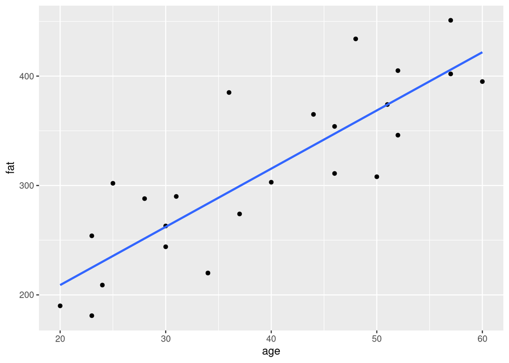

```r
ggplot(blood_fat, aes(x = age, y = fat)) +
geom_point() +
geom_smooth(method = "lm", se = FALSE)
```

4. Add a new column to the `blood_fat` data frame containing the expected fat levels from the linear model.
   - For each subject in the data frame, add these predicted values as **red points** on your previous plot.
   - Using `geom_segment()`, connect the expected values to the measured values as **dotted lines**.

remember to use the appropriate `broom` function after the linear model, to fetch all those information in one tibble

```r
# Write your answer here

#new = lm(fat ~ age, data = .))
fit <- lm(fat ~ age, data = blood_fat)
blood_fat %>% mutate(expected = predict(fit))
```

```
## # A tibble: 25 × 6
##       id   one weight   age   fat expected
##    <dbl> <dbl>  <dbl> <dbl> <dbl>    <dbl>
##  1     1     1     84    46   354     347.
##  2     2     1     73    20   190     209.
##  3     3     1     65    52   405     379.
##  4     4     1     70    30   263     262.
##  5     5     1     76    57   451     406.
##  6     6     1     69    25   302     236.
##  7     7     1     63    28   288     252.
##  8     8     1     72    36   385     294.
##  9     9     1     79    57   402     406.
## 10    10     1     75    44   365     337.
## # … with 15 more rows
```

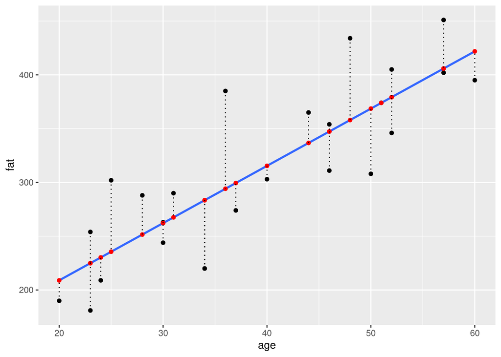

```r
augment(fit) %>%
ggplot(aes(x = age, y = fat)) +
geom_point() +
geom_smooth(method = "lm", se = FALSE) +
geom_point(aes(y = .fitted), colour = "red") +
geom_segment(aes(xend = age,
yend = .fitted),
linetype = "dotted")
```

5. Calculate the **slope** and **intercept** of the regression line

```r
# Write your answer here
#intercept
coef(fit)[1]
```

```
## (Intercept)
##    102.5751
```

```r
#slope
coef(fit)[2]
```

```
##      age
## 5.320676
```

6. draw a **dashed lightblue** line using **explicitly** the values you calculated in the previous question

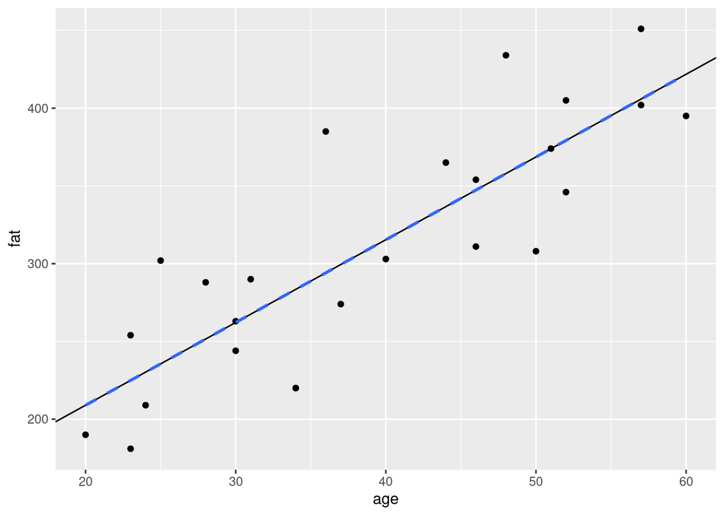

```r
# Write your answer here
ggplot(blood_fat, aes(x = age, y = fat)) +
geom_point() +
geom_abline(slope = coef(fit)[2], intercept = coef(fit)[1]) +
geom_smooth(method = "lm", se = FALSE, linetype = "dashed")
```

### Calculate $R^2$

You learned that $R^2$ can be calculated as follows:

$$R^2 = 1- \frac{\sum(y_i - \hat{y_i})^2}{\sum(y_i - \bar{y})^2} = 1- \frac{RSS}{TSS}$$

7. The length of the dotted lines you just represented are related to a term of this equation. Which one?

[HMD:] The dotted lines represent residuals, i.e., the distance between the real value and the predicted values of the regression. Therefore, they are related to RSS. But RSS is sum of the squares. So if we sum up the square of the residuals, we obtain RSS

8. Using `mutate()`, add the length of each dotted line to the `blood_fat` data frame.

```r
# Write your answer here
my_residuals <- abs(blood_fat$fat - predict(fit))
head(my_residuals)
```

```
##          1          2          3          4          5          6
##  6.6737469 18.9886687 25.7496889  0.8045681 45.1463073 66.4079497
```

```r
blood_fat %>% mutate(res = my_residuals)
```

```
## # A tibble: 25 × 6
##       id   one weight   age   fat    res
##    <dbl> <dbl>  <dbl> <dbl> <dbl>  <dbl>
##  1     1     1     84    46   354  6.67
##  2     2     1     73    20   190 19.0
##  3     3     1     65    52   405 25.7
##  4     4     1     70    30   263  0.805
##  5     5     1     76    57   451 45.1
##  6     6     1     69    25   302 66.4
##  7     7     1     63    28   288 36.4
##  8     8     1     72    36   385 90.9
##  9     9     1     79    57   402  3.85
## 10    10     1     75    44   365 28.3
## # … with 15 more rows
```

9. What do these length represent? Which functions in *R* generates these values?

[HMD:] They represent the distance between y and y_hat.

```r
# Write your answer here
residuals(fit)
```

```
##            1            2            3            4            5            6
##   6.67374689 -18.98866868  25.74968894   0.80456808  45.14630732  66.40794970
##            7            8            9           10           11           12
##  36.44592073  90.88051013  -3.85369268  28.31509954 -21.27137398  22.48389175
##           13           14           15           16           17           18
## -33.25031106  29.04930235 -26.81572165  76.03239424 -63.47813722   0.07036527
##           19           20           21           22           23           24
## -60.60895841 -63.47813722 -36.32625311 -43.95069765 -25.44016619 -12.40219517
##           25
## -18.19543192
```

10. Draw a **darkgreen** horizontal line showing the mean fat concentration of all measures.
11. Use `geom_segment()` to connect all points representing the real measures to their projection on this horizontal line (using a **darkgreen** color with **alpha = 0.2** and a **size of 2**).

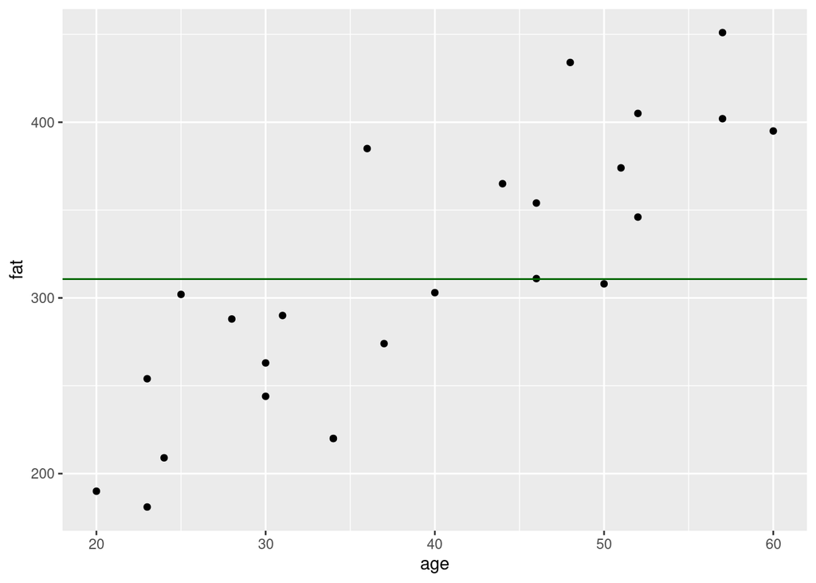

```r
# Write your answer here
ggplot(blood_fat, aes(x = age, y = fat)) +
  geom_point() +
 geom_hline(aes(yintercept = mean(blood_fat$fat) ), color="darkgreen")
```

```r
blood_fat
```

```
## # A tibble: 25 × 5
##       id   one weight   age   fat
##    <dbl> <dbl>  <dbl> <dbl> <dbl>
##  1     1     1     84    46   354
##  2     2     1     73    20   190
##  3     3     1     65    52   405
##  4     4     1     70    30   263
##  5     5     1     76    57   451
##  6     6     1     69    25   302
##  7     7     1     63    28   288
##  8     8     1     72    36   385
##  9     9     1     79    57   402
## 10    10     1     75    44   365
## # … with 15 more rows
```

12. Using `mutate()`, add the length of each green translucid line to the `blood_fat` data frame. What do they represent? And the sum of their squared length?

Those lines are deviation to the global mean of the response

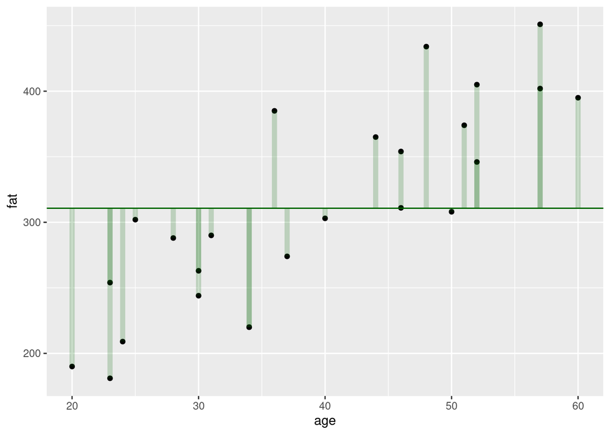

```r
# Write your answer here
ggplot(blood_fat, aes(x = age, y = fat)) +
  geom_point() +
  geom_hline(aes(yintercept = mean(blood_fat$fat) ),
            color="darkgreen") +
  geom_segment(aes(xend = age,
                   yend = mean(blood_fat$fat)),
               color="darkgreen", size=2, alpha=0.2)
```

13. Calculate $RSS$, $TSS$ and $R^2$

```r
# Write your answer here
RSS = sum(residuals(fit)^2)
TSS = sum((blood_fat$fat - mean(blood_fat$fat))^2)

R2 = 1 - (RSS/TSS)
cat("RSS is", RSS, "\n")
```

```
## RSS is 43444.37
```

```r
cat("TSS is", TSS, "\n")
```

```
## TSS is 145377
```

```r
cat(c("R2 is", R2, "\n"))
```

```
## R2 is 0.701160690236813
```

```r
# Write your answer here
```

14. Is there really a relationship between blood fat content and age?
15. What does the value of $R^2$ tell you?

```r
# Write your answer here`
```

### Checking the residuals of the model

16. Residuals’s mean
    - What is the expectation for the residuals’s mean?
    - Compute the residuals’s mean for the fat explained by age model.

```r
# Write your answer here
mean(residuals(fit))
```

```
## [1] 5.878631e-16
```

17. Can the measures appropriately be modelled in this way? Draw two diagnosis plots using `ggplot2`
    - In the first draw the residuals on the *y* axis and the estimated values on the *x* axis
    - Your second one should be a quantile-quantile plot.

The package `ggfortify` and the function `autoplot(fit)` can produce the classic 4 diagnostic plots with no efforts

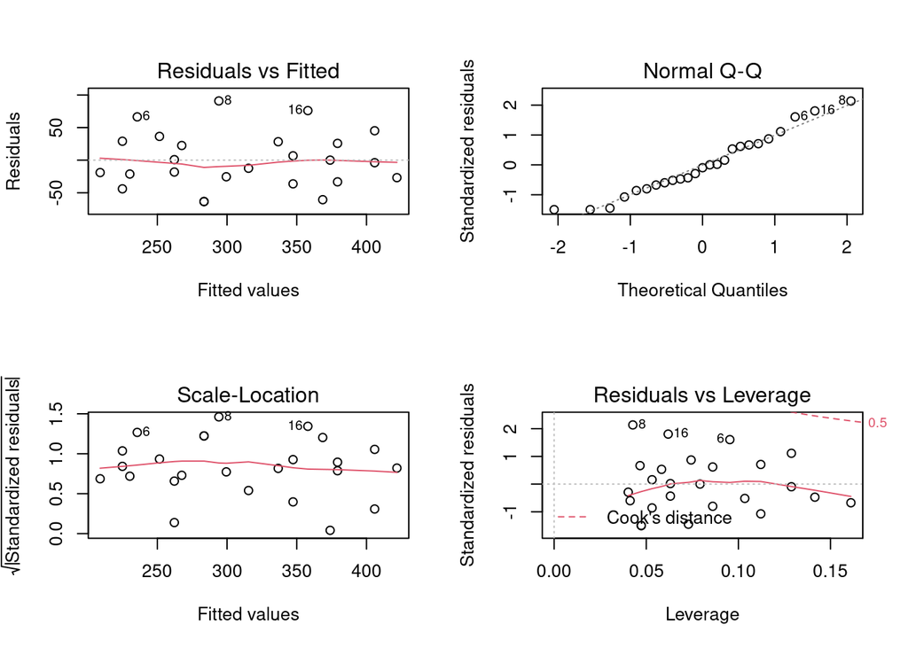

```r
# Write your answer here
par(mfrow = (c(2, 2)))
plot(lm(fat ~ age, data = blood_fat))
```

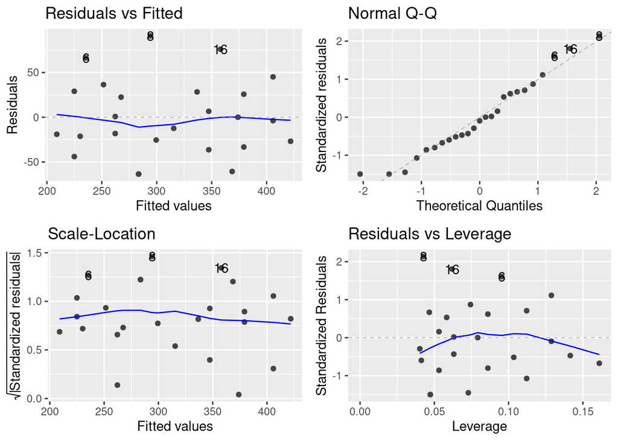

```r
autoplot(fit)
```

### Relation of blood fat content and weight

18. Change predictor and use `weight` instead of `age` to predict the fat concentration

```r
# Write your answer here
fit_w <- lm(fat ~ weight, data = blood_fat)
blood_fat %>% mutate(expected_w = predict(fit_w))
```

```
## # A tibble: 25 × 6
##       id   one weight   age   fat expected_w
##    <dbl> <dbl>  <dbl> <dbl> <dbl>      <dbl>
##  1     1     1     84    46   354       336.
##  2     2     1     73    20   190       318.
##  3     3     1     65    52   405       305.
##  4     4     1     70    30   263       313.
##  5     5     1     76    57   451       323.
##  6     6     1     69    25   302       311.
##  7     7     1     63    28   288       302.
##  8     8     1     72    36   385       316.
##  9     9     1     79    57   402       327.
## 10    10     1     75    44   365       321.
## # … with 15 more rows
```

19. Check the summary and diagnostic plots for this regression

```r
# Write your answer here
summary(fit_w)
```

```
##
## Call:
## lm(formula = fat ~ weight, data = blood_fat)
##
## Residuals:
##      Min       1Q   Median       3Q      Max
## -127.729  -53.686   -9.239   46.537  128.404
##
## Coefficients:
##             Estimate Std. Error t value Pr(>|t|)
## (Intercept)  199.298     85.818   2.322   0.0294 *
## weight         1.622      1.229   1.320   0.2000
## ---
## Signif. codes:  0 '***' 0.001 '**' 0.01 '*' 0.05 '.' 0.1 ' ' 1
##
## Residual standard error: 76.65 on 23 degrees of freedom
## Multiple R-squared:  0.07038,    Adjusted R-squared:  0.02996
## F-statistic: 1.741 on 1 and 23 DF,  p-value: 0.2
```

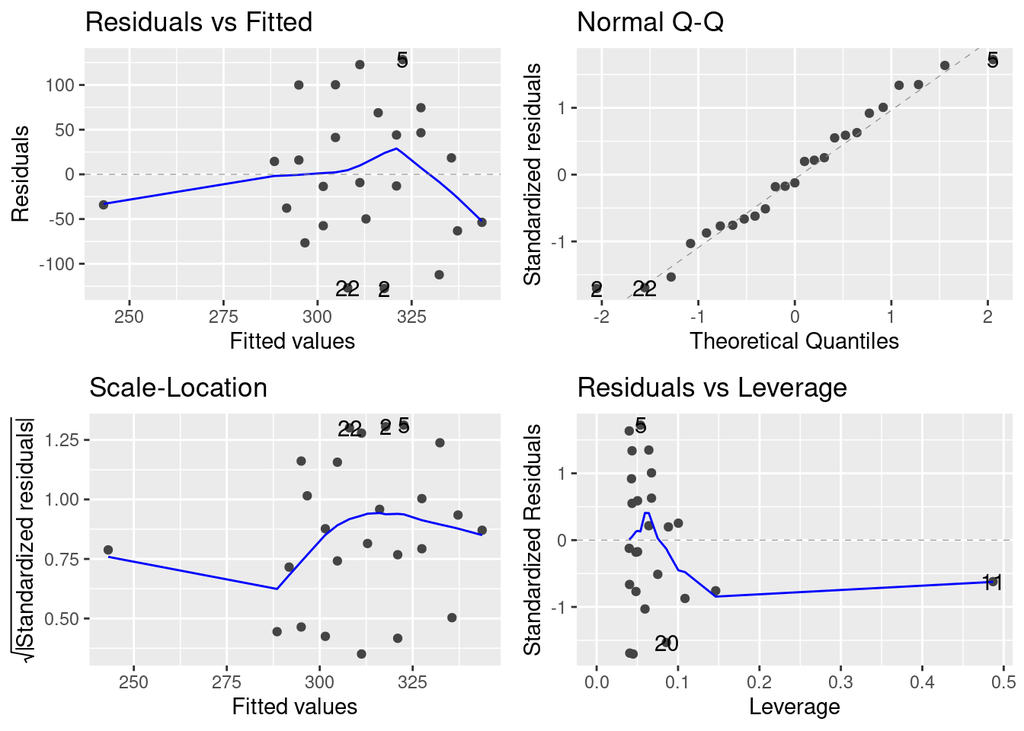

```r
autoplot(fit_w)
```

```r
# Write your answer here
```

20. Can the blood content in fat be explained by the weight of the subject?

```r
# Write your answer here
```

[HMD:] No they can’t for the following reasons: 1. From the summary table, we see that the $R^2$ score is near 0.07 which is close to 0. Moreover, the standard error is near 85 which is high.

It is also apparent in “Residuals vs Fitted” plot that the line is not near horizontal (thus distant from zero) so we have high residuals.

# 2. Multiple linear regression

## Simulated data

We are going to manipulate data where the relationship between the variables is simulated. This example comes from Gareth *et al.* 2013.

### Generate the data

21. Use the following code to generate the data:

```r
set.seed(1)
simul1 <- tibble(x1 = runif(100),
                     x2 = 0.5 * x1 + rnorm(100) / 10,
                     y  = 2 + 2 * x1 + 0.3 * x2 +(rnorm(100)))

glimpse(simul1)
```

```
## Rows: 100
## Columns: 3
## $ x1 <dbl> 0.26550866, 0.37212390, 0.57285336, 0.90820779, 0.20168193, 0.89838…
## $ x2 <dbl> 0.172564920, 0.124859310, 0.320538651, 0.341167585, 0.244143336, 0.…
## $ y  <dbl> 3.0329739, 2.7631458, 2.9237999, 2.9894037, 0.9891466, 2.9157575, 5…
```

### Variable *y* is using a linear model

22. Write the equation (as text in your markdown document)
23. Write the regression coefficients (as text in your markdown document)

[HMD:]  
$y = 2 + 2 * x_1 + 0.3 * x_2 +(rnorm(100)))$  
Coefficients: 2, 0.3

```r
# Write your answer here
```

24. Plot the relationship between *x1* and *x2*. You might want to display all relationships using `ggpairs`

`ggpairs` comes from the package `GGally`

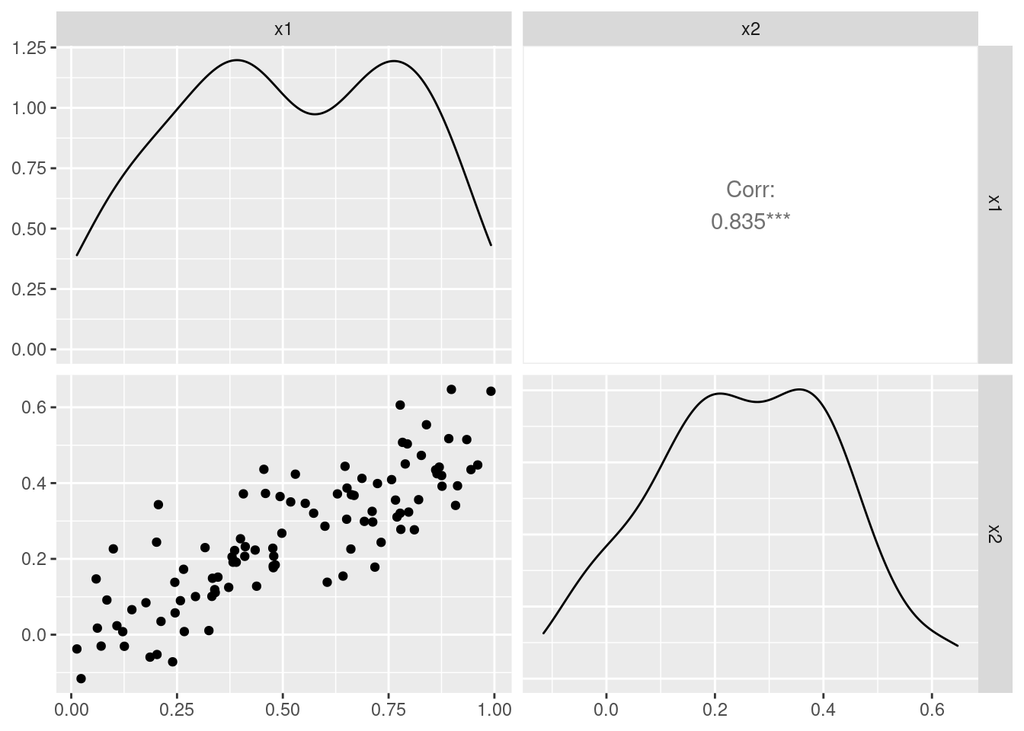

```r
# Write your answer here
ggpairs(simul1, columns = 1:2)
```

25. What is the Pearson’s correlation coefficient between *x1* and *x2*?

```r
# Write your answer here
cor(simul1$x1, simul1$x2)
```

```
## [1] 0.8351212
```

26. Will the correlation between predictors be a problem for the linear regression you just wrote down?
27. Name this effect.

[HMD:] When two predictors are correlated, you will have a range of options that give the same regression and that is a problem. For instance, we will same adjusted square for models with different number of predictors, but we prefer the simpler one. The correlated variable is not significant. I think the effect is called fake effect due to a masked variable

```r
# Write your answer here
```

28. Fit a linear model explaining *y* by *x1 + x2* and describe the summary results.

```r
# Write your answer here
lm(y ~ x1 + x2,data = simul1) %>% summary()
```

```
##
## Call:
## lm(formula = y ~ x1 + x2, data = simul1)
##
## Residuals:
##     Min      1Q  Median      3Q     Max
## -2.8311 -0.7273 -0.0537  0.6338  2.3359
##
## Coefficients:
##             Estimate Std. Error t value Pr(>|t|)
## (Intercept)   2.1305     0.2319   9.188 7.61e-15 ***
## x1            1.4396     0.7212   1.996   0.0487 *
## x2            1.0097     1.1337   0.891   0.3754
## ---
## Signif. codes:  0 '***' 0.001 '**' 0.01 '*' 0.05 '.' 0.1 ' ' 1
##
## Residual standard error: 1.056 on 97 degrees of freedom
## Multiple R-squared:  0.2088, Adjusted R-squared:  0.1925
## F-statistic:  12.8 on 2 and 97 DF,  p-value: 1.164e-05
```

29. Do you accept $H_0: \hat{\beta_1} = 0$ and $H_0: \hat{\beta_2} = 0$?

```r
# Write your answer here
```

30. Fit a linear model explaining *y* by *x1* alone.
31. Do you accept $H_0: \hat{\beta_1} = 0$? What happened?

```r
# Write your answer here
lm(y ~ x1 ,data = simul1) %>% summary()
```

```
##
## Call:
## lm(formula = y ~ x1, data = simul1)
##
## Residuals:
##      Min       1Q   Median       3Q      Max
## -2.89495 -0.66874 -0.07785  0.59221  2.45560
##
## Coefficients:
##             Estimate Std. Error t value Pr(>|t|)
## (Intercept)   2.1124     0.2307   9.155 8.27e-15 ***
## x1            1.9759     0.3963   4.986 2.66e-06 ***
## ---
## Signif. codes:  0 '***' 0.001 '**' 0.01 '*' 0.05 '.' 0.1 ' ' 1
##
## Residual standard error: 1.055 on 98 degrees of freedom
## Multiple R-squared:  0.2024, Adjusted R-squared:  0.1942
## F-statistic: 24.86 on 1 and 98 DF,  p-value: 2.661e-06
```

32. Fit a linear model explaining *y* by *x2* alone.
33. Do you accept $H_0: \hat{\beta_1} = 0$?  
    What happened?

I reject the hypothesis again because the p-value is not greater than alpha. But the estimator of $x_1$ have greater value, implying that when we remove the masked effect of $x_2$, we can see that $x_1$ has greater effect now.

```r
# Write your answer here
```

### One observation was unfortunately forgotten and is:

`x1 = 0.1, x2 = 0.8, y = 6` (@) Add it to the existing `simul1` and store the result as `simul2`.

Have a look at the function `add_row()` defined in the package `tibble`

```r
simul2 <- add_row(simul1, x1 = 0.1, x2 = 0.8, y = 6)
```

```r
# Write your answer here
cor(simul2$x1, simul2$x2)
```

```
## [1] 0.7392279
```

34. Plot the relationship between *x1* and *x2* again using the updated dataset `simul2`.

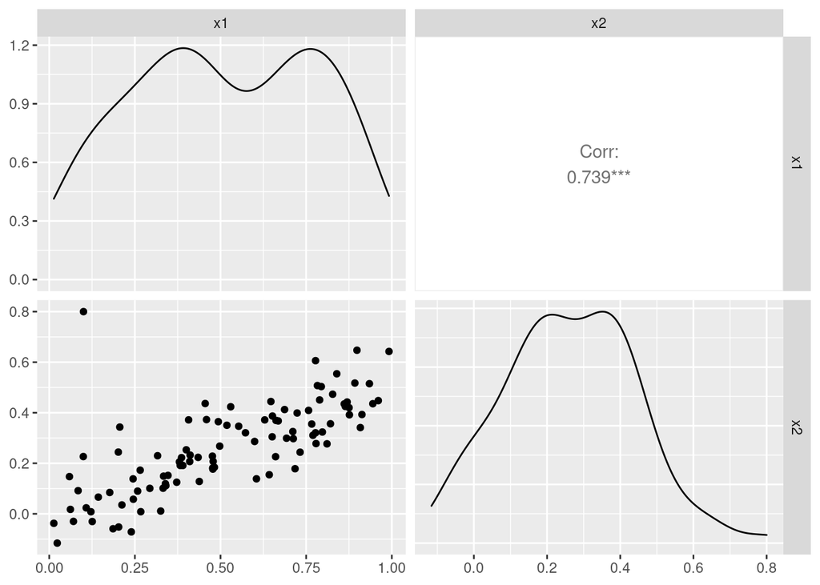

```r
# Write your answer here
ggpairs(simul2, columns = 1:2)
```

35. Fit the previous linear model again using `simul2`

```r
lm(y ~ x1, data = simul2) %>% glance()
```

```
## # A tibble: 1 × 12
##   r.squared adj.r.squared sigma statistic   p.value    df logLik   AIC   BIC
##       <dbl>         <dbl> <dbl>     <dbl>     <dbl> <dbl>  <dbl> <dbl> <dbl>
## 1     0.156         0.148  1.11      18.3 0.0000429     1  -153.  312.  320.
## # … with 3 more variables: deviance <dbl>, df.residual <int>, nobs <int>
```

```r
lm(y ~ x2, data = simul2) %>% glance()
```

```
## # A tibble: 1 × 12
##   r.squared adj.r.squared sigma statistic    p.value    df logLik   AIC   BIC
##       <dbl>         <dbl> <dbl>     <dbl>      <dbl> <dbl>  <dbl> <dbl> <dbl>
## 1     0.212         0.204  1.07      26.7 0.00000125     1  -149.  305.  313.
## # … with 3 more variables: deviance <dbl>, df.residual <int>, nobs <int>
```

```r
lm(y ~ x1 + x2, data = simul2) %>% glance()
```

```
## # A tibble: 1 × 12
##   r.squared adj.r.squared sigma statistic    p.value    df logLik   AIC   BIC
##       <dbl>         <dbl> <dbl>     <dbl>      <dbl> <dbl>  <dbl> <dbl> <dbl>
## 1     0.219         0.203  1.07      13.7 0.00000556     2  -149.  306.  317.
## # … with 3 more variables: deviance <dbl>, df.residual <int>, nobs <int>
```